# Table of Contents

# Computational instruction with Jupyter notebooks

Philip Austin, Department of Earth, Ocean and Atmospheric Sciences, UBC

Notebook available at https://github.com/phaustin/mcgill_2019_talk

## Part 1 -- Infrastructure

- Linux/git
- Conda-forge
- Jupyter/Jupytext
- Cocalc
- nbgrader
- nbsphinx
- pangeo

## Part 2 -- Examples

- 2nd year course, 48 students
  - Jupyter/chrome/cocalc
- 3rd/4th year course, 26 students
  - Jupyter/laptops/conda-forge
- Grad/postdoc workshop, 20 students,
  - pangeo with dask/xarray,zarr on an HPC cluster

## Some history

**July, 1997: BAMS article: John Stockie, Susan Allen, Phil Austin**

*An Interactive Course in Numerical Methods for the Earth Sciences*

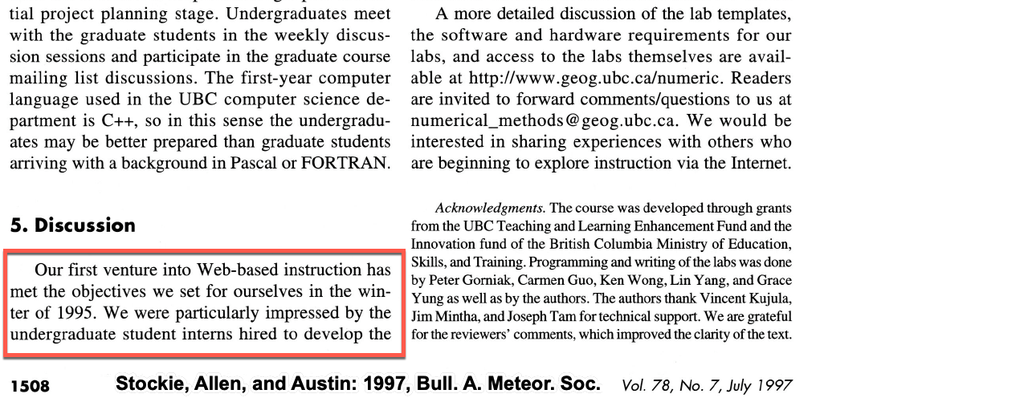

```python
Image(filename='figures/bams_ref.png')
```

## Infrastructure

### Linux kernel

- developed by 19,000 unique committers
- 65,000 files
- 25 million lines of code

### Git and Github

- 2005: [Linus Torvalds](https://en.wikipedia.org/wiki/Linus_Torvalds) begins [Git development](https://en.wikipedia.org/wiki/Git)
- 2008: [Github founded](https://en.wikipedia.org/wiki/GitHub), in 2018 it hosted 28 million users and 57 million repositories
- Distributed version control makes possible the
  - [pull request workflow](https://yangsu.github.io/pull-request-tutorial/)

### Conda-forge

- Software packaging using [conda](https://conda.io/projects/conda/en/latest/index.html)
- Supported by [numfocus](https://numfocus.org/project/conda-forge) -- provides scientifc software for linux, macos and windows 10 ~ 3500 separate packages
  - [netcdf-fortran feedstock](https://github.com/conda-forge/netcdf-fortran-feedstock)
  - [gdal feedstock](https://github.com/conda-forge/gdal-feedstock)

### Jupyter and jupytext

- [Jupyter](https://blog.jupyter.org/jupyter-receives-the-acm-software-system-award-d433b0dfe3a2)
  - Origins -- began in 2001 as ipython: repl (read, evaluate, print, loop)
  - [Hosts 100 language kernels](https://github.com/jupyter/jupyter/wiki/Jupyter-kernels)
- jupytext
  - round trip conversion between jupyter notebooks written in javascript and
    - python, R, markdown, Julia, bash scripts
    - Allows collaborative notebook development uisng pull-requests
    - Example: [this talk](https://github.com/phaustin/mcgill_2019_talk/blob/master/talk_dir/python/mcgill_talk.py)

### Cocalc, nbgrader and nbsphinx

- cocalc.com: juypter notebook hosting for classes
- nbgrader: autograded jupyter notebooks
- nbsphinx: build a webstie from notebooks

## Examples

### Inspiration

- [Cliburn Chan's Stat 663](http://people.duke.edu/~ccc14/sta-663-2018/index.html)
- [Berkeley's data 8](https://data.berkeley.edu/education/courses/data-8)

### Large class, 2nd year

- [Computational Methods in Geological Engineering](https://phaustin.github.io/eosc213/)
  - co-taught with Roger Beckie and Nicolas Seigneur
  - 48 2nd year geological engineering students
  - Prereqs: vector calculus, linear algebra, C
  - students use: cocalc.com notebooks

### Smaller class, 3rd and 4th year

- 3rd/4th year: [Radiation and remote sensing](https://phaustin.github.io/a301_code/)
  - taught to 26 students in EOSC and other departments
  - open to any student with 1st year calculus, physics, programming
  - includes both jupyter notebooks and course libraries
  - students ues: conda environments on laptops or lab desktops

### Grad/post-doc workshop

- [Parallel python tutorial](https://phaustin.github.io/parallel_python_course/)
- Introduce the [pangeo software stack](https://docs.google.com/presentation/d/1evNXCddIllXUt4a5jKfmlO2197sp8T6I9L650cYZcsk/edit#slide=id.g4f72134f6b_0_84), particularly [dask](https://medium.com/pangeo/dask-jobqueue-d7754e42ca53), [xarray](https://xarray.pydata.org/en/stable/) and [zarr](https://zarr.readthedocs.io/en/stable/). (see this [pangeo notebook server](https://medium.com/pangeo/pangeo-meets-binder-2ea923feb34f®))
- 20 UBC HPC focussed grad students/postdocs
- Half day, using notebooks and Compute Canada cluster

## Take home points

Jupyter notebooks plus conda-forge and github.

- Make active learning possible at scale. Costs to students are similar to the price they are paying for textbooks (cocalc plus a tablet/chromebook)
- In-class sessions and assignments deal with working examples of realistic problems and best-practices for production computing
- Use the same workflow for both research and teaching, and make research reproducible by default.

## What's next?

- I am writing an instructor's guide to teaching with Jupyter notebooks
- EOAS is creating a github repository for collaborative notebook development focussing on UCAR/ACCRU institutions, watch the UCAR members/ACCRU mailing lists
- Questions/interest/want to help? Email me at paustin@eoas.ubc.ca

> "The future is already here — it's just not very evenly distributed." -- William Gibson